# On Trees 🌳

## Using the caret package and rpart method

```r
class_tree2 <- train(High ~ ., data = train_dataC, method = "rpart")
class_tree2
```

```
CART

200 samples
 10 predictor
  2 classes: 'No', 'Yes'

No pre-processing
Resampling: Bootstrapped (25 reps)
Summary of sample sizes: 200, 200, 200, 200, 200, 200, ...
Resampling results across tuning parameters:

  cp          Accuracy   Kappa
  0.04878049  0.7348796  0.4574667
  0.10975610  0.7159441  0.4016948
  0.29268293  0.6674065  0.2582073

Accuracy was used to select the optimal model using the largest value.
The final value used for the model was cp = 0.04878049.
```

We can find the pruned tree using rpart.plot

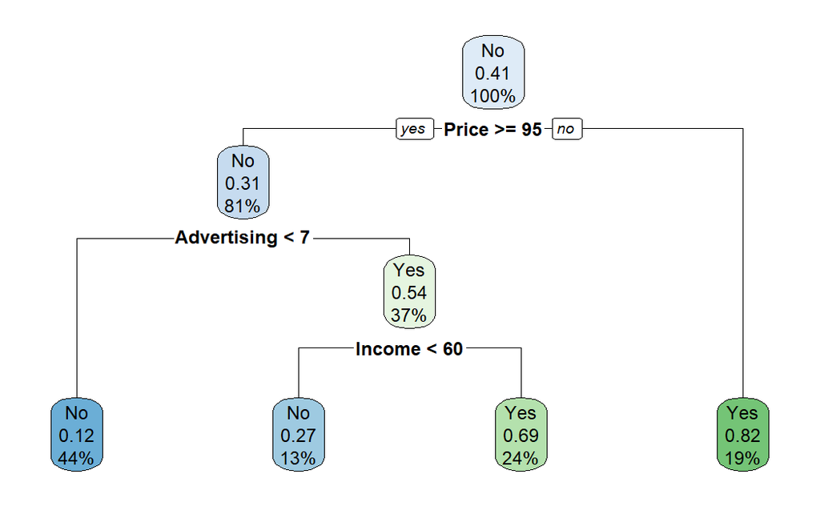

Use the test data to predict

```r
class_tree2_pred<-predict(class_tree2, test_dataC)
confusionMatrix(class_tree2_pred, test_dataC$High)
```

```
Confusion Matrix and Statistics

          Reference
Prediction No Yes
       No  80  36
       Yes 38  46

               Accuracy : 0.63
                 95% CI : (0.5591, 0.697)
    No Information Rate : 0.59
    P-Value [Acc > NIR] : 0.1403

                  Kappa : 0.2381

 Mcnemar's Test P-Value : 0.9075

            Sensitivity : 0.6780
            Specificity : 0.5610
         Pos Pred Value : 0.6897
         Neg Pred Value : 0.5476
             Prevalence : 0.5900
         Detection Rate : 0.4000
   Detection Prevalence : 0.5800
      Balanced Accuracy : 0.6195

       'Positive' Class : No
```

When you are using k-fold cross-validation, you use the same method as above except you add a control term.

# Bagging and Random Forest

We are going to use the boston data again!! Remember we called it ‘data’ in the regression portion..

Also, remember that we already partitioned the data!

## Bagging

```r
bag_boston <- randomForest(medv ~ ., data = train_data, mtry=12, importance = TRUE)
bag_boston
```

```
Call:
 randomForest(formula = medv ~ ., data = train_data, mtry = 12,      importance = TRUE)
               Type of random forest: regression
                     Number of trees: 500
No. of variables tried at each split: 12

          Mean of squared residuals: 10.66224
                    % Var explained: 87.95
```

Checking performance!

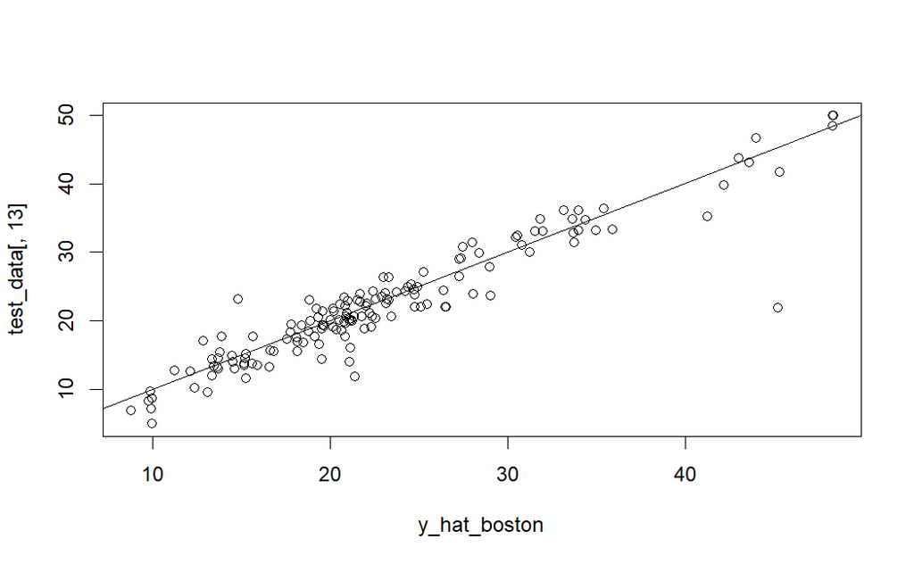

```r
y_hat_boston<-predict(bag_boston, test_data)
plot(y_hat_boston, test_data[, 13])
abline(0,1)
```

```r
mean((y_hat_boston-test_data[,13])^2)
```

```
[1] 9.333436
```

Remember our last value was ~18, now we have ~9 which gives us a root of ~3, this is comparatively better!

We can change the number of trees by using the ‘ntree’ argument.

```r
bag_boston_again <- randomForest(medv ~ ., data = train_data, mtry=12, importance = TRUE, ntree=25)
bag_boston_again
```

```
Call:
 randomForest(formula = medv ~ ., data = train_data, mtry = 12,      importance = TRUE, ntree = 25)
               Type of random forest: regression
                     Number of trees: 25
No. of variables tried at each split: 12

          Mean of squared residuals: 12.55295
                    % Var explained: 85.81
```

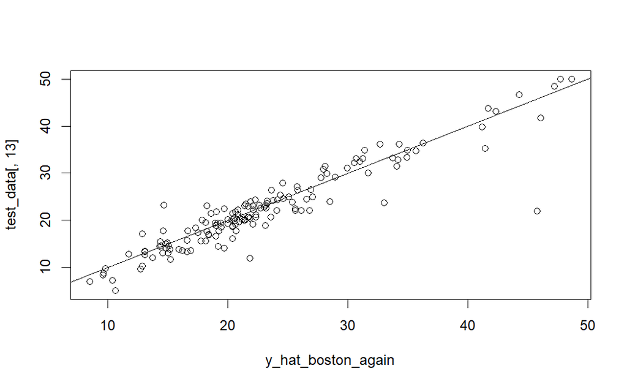

```r
y_hat_boston_again<-predict(bag_boston_again, test_data)
plot(y_hat_boston_again, test_data[, 13])
abline(0,1)
```

```r
mean((y_hat_boston_again-test_data[,13])^2)
```

```
[1] 10.06201
```

## Random Forest

Growing a random forest tree proceeds exactly in the same way, except that we use a smaller value for mtry. By default, randomForest() uses p/3 variables when building a random forest of regression trees and sqrt(p) variables when building a random forest of classification trees.

Let us try a random forest with mtry = 6

```r
rf_boston <- randomForest(medv ~ ., data = train_data, mtry=6, importance = TRUE, ntree=25)
rf_boston
```

```
Call:
 randomForest(formula = medv ~ ., data = train_data, mtry = 6,      importance = TRUE, ntree = 25)
               Type of random forest: regression
                     Number of trees: 25
No. of variables tried at each split: 6

          Mean of squared residuals: 12.28964
                    % Var explained: 86.11
```

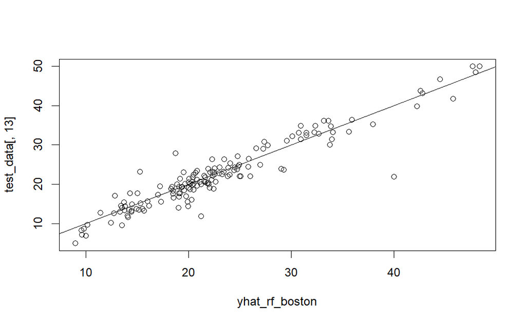

```r
yhat_rf_boston <- predict(rf_boston, test_data)
plot(yhat_rf_boston, test_data[,13])
abline(0,1)
```

```r
mean((yhat_rf_boston-test_data[,13])^2)
```

```
[1] 7.977608
```

Now our result is even better!

We can use the importance() function to see the importance of each variable

```r
importance(rf_boston)
```

```
           %IncMSE IncNodePurity
crim     3.4830546    2626.36617
zn      -0.2908547      48.48726
indus    2.9149676    1110.39137
chas     2.1229594      27.94134
nox      4.6829407    1717.20393
rm      11.0514298    9720.91429
age      2.3858268     734.14088
dis      4.5151646    1467.90968
rad      0.9885928     150.30091
tax      2.1680481     685.52671
ptratio  2.6507770    1455.43163
lstat    8.1393413   11452.46876
```

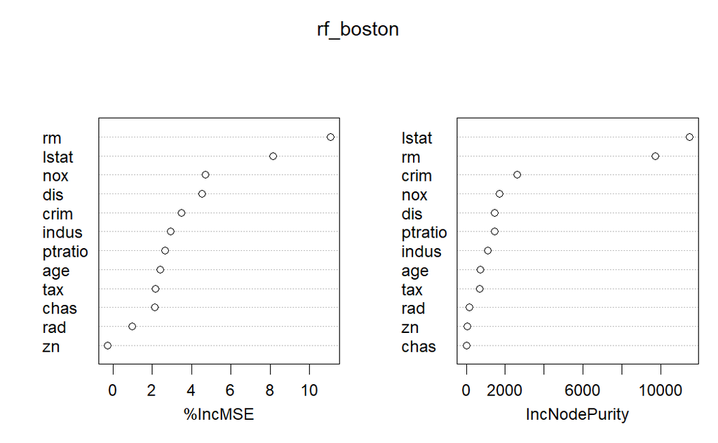

This would be how you visualize the importance of your variables. From above we can see that lstat and rm are the most important. Previously, we were able to see this in the simple pruned decision tree!

# Boosting

Still working in the Boston data set

We will use the gbm package and the Boston dataset to apply boosting:

gbm has four tuning parameters

- n.trees (# of Boosting Iterations)
- interaction.depth (Max Tree Depth i.e. the number of splits in each tree d)
- shrinkage parameter (typically 0.01 or 0.001 and if nothing specified gbm uses a default of 0.001)
- n.minobsinnode (Minimum Terminal Node Size)

|  | var | rel.inf |
| --- | --- | --- |
| lstat | lstat | 37.2474567 |
| rm | rm | 29.5545538 |
| dis | dis | 10.0132782 |
| crim | crim | 5.9940793 |
| nox | nox | 5.1296614 |
| age | age | 4.8259694 |
| ptratio | ptratio | 3.1288187 |
| tax | tax | 1.7692636 |
| rad | rad | 0.8882689 |
| indus | indus | 0.7735834 |

[output cut: 2 more lines]

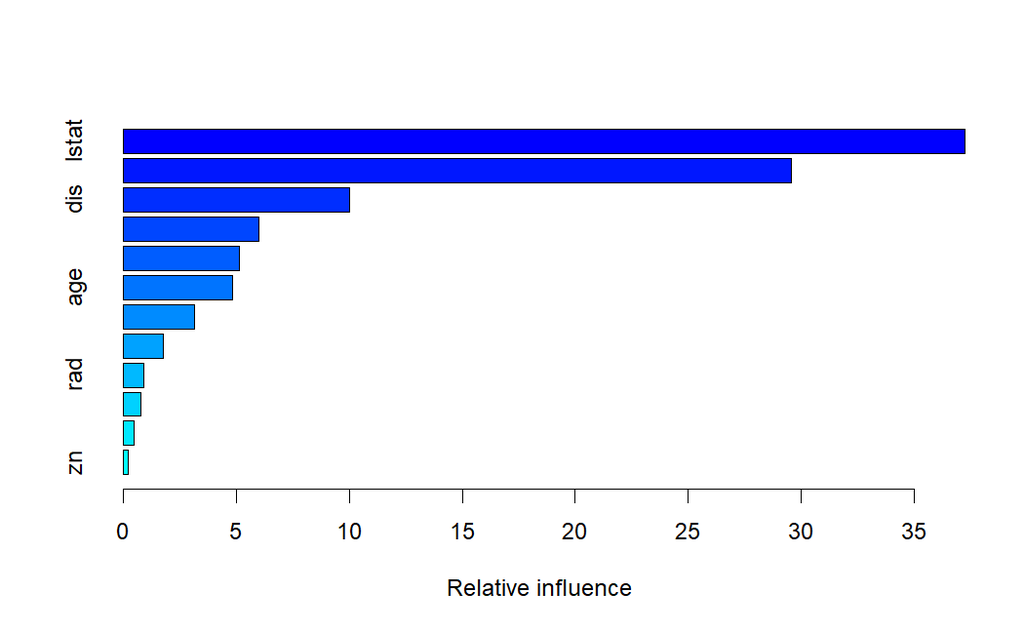

```r
boost_model <- gbm(medv ~., data = train_data, distribution="gaussian", n.trees = 5000, interaction.depth = 4)
summary(boost_model)
```

Based on the relative influence obtained above, we can plot the marginal effects of the most influential variables using partial dependence plots (PDPs). You can learn more about PDPs here and here.

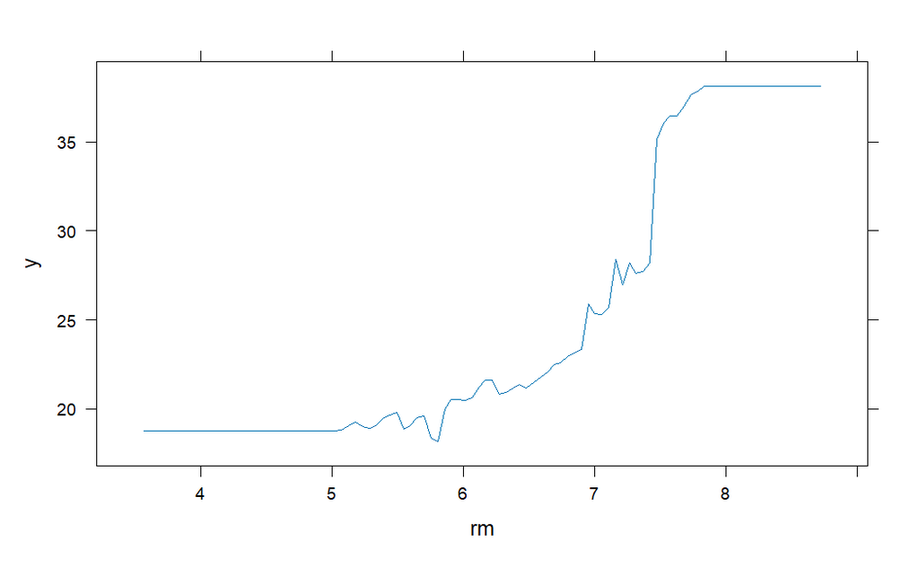

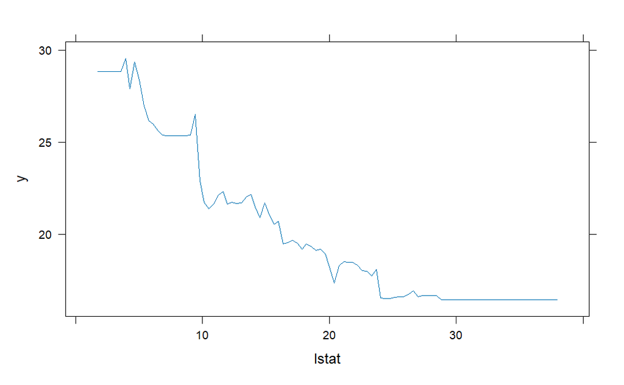

Let us use the test data for prediction

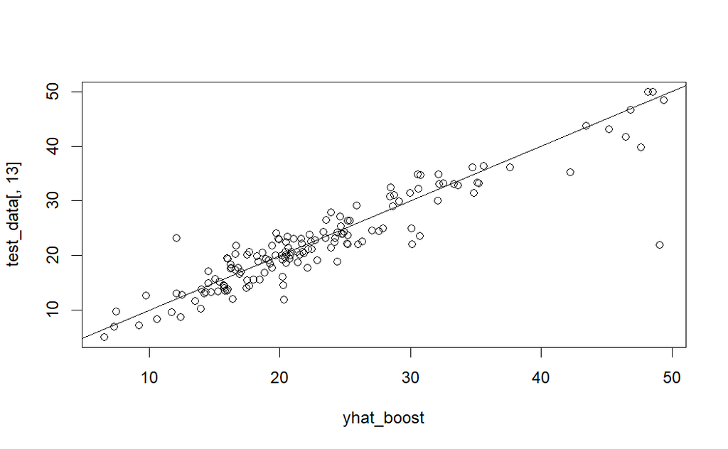

```r
yhat_boost <- predict(boost_model, test_data, n.trees=5000)
plot(yhat_boost, test_data[, 13])
abline(0,1)
```

```r
mean((yhat_boost-test_data[, 13])^2)
```

```
[1] 12.87078
```